# Narrated: Foundations Case Study

Independent/Group work

The LASER Team

## 0. INTRODUCTION

We will focus on online science classes provided through a state-wide online virtual school and conduct an analysis that help product students’ performance in these online courses. This case study is guided by a foundational study in Learning Analytics that illustrates how analyses like these can be used develop an early warning system for educators to identify students at risk of failing and intervene before that happens.

Over the next labs we will dive into the Learning Analytics Workflow as follows:

1. **Prepare**: Prior to analysis, it’s critical to understand the context and data sources you’re working with so you can formulate useful and answerable questions. You’ll also need to become familiar with and load essential packages for analysis, and learn to load and view the data for analysis.
2. **Wrangle**: Wrangling data entails the work of manipulating, cleaning, transforming, and merging data. In Part 2 we focus on importing CSV files, tidying and joining our data.
3. **Explore**: In Part 3, we use basic data visualization and calculate some summary statistics to explore our data and see what insight it provides in response to our questions.
4. **Model:** After identifying variables that may be related to student performance through exploratory analysis, we’ll look at correlations and create some simple models of our data using linear regression.
5. **Communicate:** To wrap up our case study, we’ll develop our first “data product” and share our analyses and findings by creating our first web page using R Markdown.

## 1. PREPARE

This case study is guided by a well-cited publication from two authors that have made numerous contributions to the field of Learning Analytics over the years. This article is focused on “early warning systems” in higher education, and where adoption of learning management systems (LMS) like Moodle and Canvas gained a quicker foothold.

Macfadyen, L. P., & Dawson, S. (2010). [Mining LMS data to develop an “early warning system” for educators: A proof of concept.](https://www.sciencedirect.com/science/article/pii/S0360131509002486?via%3Dihub) *Computers & education*, *54*(2), 588-599.

#### ABOUT the study

Previous research has indicated that universities and colleges could utilize Learning Management System (LMS) data to create reporting tools that identify students who are at risk and enable prompt pedagogical interventions. The present study validates and expands upon this idea by presenting data from an international research project that explores the specific online activities of students that reliably indicate their academic success. This paper confirms and extends this proposition by providing data from an international research project investigating **which student online activities accurately predict academic achievement.**

The **data analyzed** in this exploratory research was extracted from the **course-based instructor tracking logs** and the BB Vista production server.

Data collected on each student included ‘whole term’ counts for frequency of usage of course materials and tools supporting content delivery, engagement and discussion, assessment and administration/management. In addition, tracking data indicating total time spent on certain tool-based activities (assessments, assignments, total time online) offered a total measure of individual student time on task.

The authors used scatter plots for identifying potential relationships between variables under investigation, followed by a a simple correlation analysis of each variable to further interrogate the significance of selected variables as indicators of student achievement. Finally, a linear multiple regression analysis was conducted in order to develop a predictive model in which a student final grade was the continuous dependent variable.

### 1a. Load Libraries

Tidyverse: Tidyverse is a collection of R packages designed for data manipulation, visualization, and analysis.

Here: The `here package` provides a simple way to manage file paths in your R projects.

```r
#Load Libraries below needed for analysis
library(tidyverse)
```

### 1b. Load in Data

Load the file from data folder.

- `log-data.csv` save object as `time-spent`
- inspect the file

#### Data Source #1: Log Data

Log-trace data is data generated from our interactions with digital technologies, such as archived data from social media postings. In education, an increasingly common source of log-trace data is that generated from interactions with LMS and other digital tools.

The data we will use has already been “wrangled” quite a bit and is a summary type of log-trace data: the number of minutes students spent on the course. While this data type is fairly straightforward, there are even more complex sources of log-trace data out there (e.g., time stamps associated with when students started and stopped accessing the course).

Let’s use the `read_csv()` function from {readr} to import our `log-data.csv` file directly from our data folder and name this data set `time_spent`, to help us to quickly recollect what function it serves in this analysis:

#### **👉 Your Turn** **⤵**

```r
# load log file from data folder
time_spent <- read_csv("data/log-data.csv")
#inspect data
time_spent
```

```
## # A tibble: 716 × 6
##    student_id course_id    gender enrollment_reason enrollment_status time_spent
##         <dbl> <chr>        <chr>  <chr>             <chr>                  <dbl>
##  1      60186 AnPhA-S116-… M      Course Unavailab… Approved/Enrolled      2087.
##  2      66693 AnPhA-S116-… M      Course Unavailab… Approved/Enrolled      2309.
##  3      66811 AnPhA-S116-… F      Course Unavailab… Approved/Enrolled      5299.
##  4      66862 AnPhA-S116-… F      Course Unavailab… Approved/Enrolled      1747.
##  5      67508 AnPhA-S116-… F      Scheduling Confl… Approved/Enrolled      2668.
##  6      70532 AnPhA-S116-… F      Learning Prefere… Approved/Enrolled      2938.
##  7      77010 AnPhA-S116-… F      Learning Prefere… Approved/Enrolled      1533.
##  8      85249 AnPhA-S116-… F      Course Unavailab… Approved/Enrolled      1210.
##  9      85411 AnPhA-S116-… F      Scheduling Confl… Approved/Enrolled       473.
## 10      85583 AnPhA-S116-… F      Scheduling Confl… Approved/Enrolled      5532.
## # ℹ 706 more rows
```

#### Data Source #2: Academic Achievement Data

Load the file from data folder.

- `gradebook-summary.csv` save object as `gradebook`
- inspect the file

We’ll load the data in the same way as earlier.

#### **👉 Your Turn** **⤵**

```r
# load grade book data from data folder
gradebook <- read_csv("data/gradebook-summary.csv")
#inspect data
gradebook
```

```
## # A tibble: 717 × 4
##    student_id course_id     total_points_possible total_points_earned
##         <dbl> <chr>                         <dbl>               <dbl>
##  1      43146 FrScA-S216-02                  1217               1150
##  2      44638 OcnA-S116-01                   1676               1384.
##  3      47448 FrScA-S216-01                  1232               1116
##  4      47979 OcnA-S216-01                   1833               1493.
##  5      48797 PhysA-S116-01                  2225               1995.
##  6      51943 FrScA-S216-03                  1222                 70
##  7      52326 AnPhA-S216-01                  1775               1519.
##  8      52446 PhysA-S116-01                  2225               2198
##  9      53447 FrScA-S116-01                  1212               1173
## 10      53475 FrScA-S116-02                  1212                  0
## # ℹ 707 more rows
```

#### Data Source #3: Self-Report Survey

Load the file from data folder.

- `survey.csv`
- inspect the file

The third data source is a self-report survey. This was data collected before the start of the course. The survey included ten items, each corresponding to one of three motivation measures: interest, utility value, and perceived competence. These were chosen for their alignment with one way to think about students’ motivation, to what extent they expect to do well (corresponding to their perceived competence) and their value for what they are learning (corresponding to their interest and utility value).

1. I think this course is an interesting subject. (Interest)
2. What I am learning in this class is relevant to my life. (Utility value)
3. I consider this topic to be one of my best subjects. (Perceived competence)
4. I am not interested in this course. (Interest—reverse coded)
5. I think I will like learning about this topic. (Interest)
6. I think what we are studying in this course is useful for me to know. (Utility value)
7. I don’t feel comfortable when it comes to answering questions in this area. (Perceived competence–reverse coded)
8. I think this subject is interesting. (Interest)
9. I find the content of this course to be personally meaningful. (Utility value)
10. I’ve always wanted to learn more about this subject. (Interest)

Let’s use the `read_csv()` function from {readr} to import our `survey.csv` file directly from our data folder and name this data set `survey`, to help us to quickly recollect what function it serves in this analysis:

#### **👉 Your Turn** **⤵**

```r
# load survey data from data folder
survey <- read_csv("data/survey.csv")
#inspect data
head(survey)
```

```
## # A tibble: 6 × 26
##   student_ID course_ID  subject semester section   int   val percomp    tv    q1
##   <chr>      <chr>      <chr>   <chr>    <chr>   <dbl> <dbl>   <dbl> <dbl> <dbl>
## 1 43146      FrScA-S21… FrScA   S216     02        4.2  3.67     4    3.86     4
## 2 44638      OcnA-S116… OcnA    S116     01        4    3        3    3.57     4
## 3 47448      FrScA-S21… FrScA   S216     01        4.2  3        3    3.71     5
## 4 47979      OcnA-S216… OcnA    S216     01        4    3.67     2.5  3.86     4
## 5 48797      PhysA-S11… PhysA   S116     01        3.8  3.67     3.5  3.71     4
## 6 51943      FrScA-S21… FrScA   S216     03        3.8  3.67     3.5  3.71     4
## # ℹ 16 more variables: q2 <dbl>, q3 <dbl>, q4 <dbl>, q5 <dbl>, q6 <dbl>,
## #   q7 <dbl>, q8 <dbl>, q9 <dbl>, q10 <dbl>, date.x <dttm>, post_int <dbl>,
## #   post_uv <dbl>, post_tv <dbl>, post_percomp <dbl>, date.y <dttm>,
## #   date <dttm>
```

## 2. WRANGLE

### 2a. Tidy data

##### Data 1: TIME SPENT

We will separate course_id variable in the time-spent.

The `c()` function in R is used to get the output by giving parameters inside the function.

```r
time_spent %>%
  separate(course_id,
           c("subject", "semester", "section"))
```

```
## # A tibble: 716 × 8
##    student_id subject semester section gender enrollment_reason
##         <dbl> <chr>   <chr>    <chr>   <chr>  <chr>
##  1      60186 AnPhA   S116     01      M      Course Unavailable at Local School
##  2      66693 AnPhA   S116     01      M      Course Unavailable at Local School
##  3      66811 AnPhA   S116     01      F      Course Unavailable at Local School
##  4      66862 AnPhA   S116     01      F      Course Unavailable at Local School
##  5      67508 AnPhA   S116     01      F      Scheduling Conflict
##  6      70532 AnPhA   S116     01      F      Learning Preference of the Student
##  7      77010 AnPhA   S116     01      F      Learning Preference of the Student
##  8      85249 AnPhA   S116     01      F      Course Unavailable at Local School
##  9      85411 AnPhA   S116     01      F      Scheduling Conflict
## 10      85583 AnPhA   S116     01      F      Scheduling Conflict
## # ℹ 706 more rows
## # ℹ 2 more variables: enrollment_status <chr>, time_spent <dbl>
```

```r
time_spent
```

```
## # A tibble: 716 × 6
##    student_id course_id    gender enrollment_reason enrollment_status time_spent
##         <dbl> <chr>        <chr>  <chr>             <chr>                  <dbl>
##  1      60186 AnPhA-S116-… M      Course Unavailab… Approved/Enrolled      2087.
##  2      66693 AnPhA-S116-… M      Course Unavailab… Approved/Enrolled      2309.
##  3      66811 AnPhA-S116-… F      Course Unavailab… Approved/Enrolled      5299.
##  4      66862 AnPhA-S116-… F      Course Unavailab… Approved/Enrolled      1747.
##  5      67508 AnPhA-S116-… F      Scheduling Confl… Approved/Enrolled      2668.
##  6      70532 AnPhA-S116-… F      Learning Prefere… Approved/Enrolled      2938.
##  7      77010 AnPhA-S116-… F      Learning Prefere… Approved/Enrolled      1533.
##  8      85249 AnPhA-S116-… F      Course Unavailab… Approved/Enrolled      1210.
##  9      85411 AnPhA-S116-… F      Scheduling Confl… Approved/Enrolled       473.
## 10      85583 AnPhA-S116-… F      Scheduling Confl… Approved/Enrolled      5532.
## # ℹ 706 more rows
```

Make sure to save it to the `time_spent` object.

```r
time_spent <- time_spent %>%
  separate(course_id,
           c("subject", "semester", "section"))


time_spent
```

```
## # A tibble: 716 × 8
##    student_id subject semester section gender enrollment_reason
##         <dbl> <chr>   <chr>    <chr>   <chr>  <chr>
##  1      60186 AnPhA   S116     01      M      Course Unavailable at Local School
##  2      66693 AnPhA   S116     01      M      Course Unavailable at Local School
##  3      66811 AnPhA   S116     01      F      Course Unavailable at Local School
##  4      66862 AnPhA   S116     01      F      Course Unavailable at Local School
##  5      67508 AnPhA   S116     01      F      Scheduling Conflict
##  6      70532 AnPhA   S116     01      F      Learning Preference of the Student
##  7      77010 AnPhA   S116     01      F      Learning Preference of the Student
##  8      85249 AnPhA   S116     01      F      Course Unavailable at Local School
##  9      85411 AnPhA   S116     01      F      Scheduling Conflict
## 10      85583 AnPhA   S116     01      F      Scheduling Conflict
## # ℹ 706 more rows
## # ℹ 2 more variables: enrollment_status <chr>, time_spent <dbl>
```

As you can see from the dataset, time_spent variable is not set as hour. Let’s change that. For this, we will use “mutate()” function.

```r
# mutate minutes to hours on time spent and save as new variable.
time_spent <- time_spent %>%
  mutate(time_spent_hours = time_spent / 60)
time_spent
```

```
## # A tibble: 716 × 9
##    student_id subject semester section gender enrollment_reason
##         <dbl> <chr>   <chr>    <chr>   <chr>  <chr>
##  1      60186 AnPhA   S116     01      M      Course Unavailable at Local School
##  2      66693 AnPhA   S116     01      M      Course Unavailable at Local School
##  3      66811 AnPhA   S116     01      F      Course Unavailable at Local School
##  4      66862 AnPhA   S116     01      F      Course Unavailable at Local School
##  5      67508 AnPhA   S116     01      F      Scheduling Conflict
##  6      70532 AnPhA   S116     01      F      Learning Preference of the Student
##  7      77010 AnPhA   S116     01      F      Learning Preference of the Student
##  8      85249 AnPhA   S116     01      F      Course Unavailable at Local School
##  9      85411 AnPhA   S116     01      F      Scheduling Conflict
## 10      85583 AnPhA   S116     01      F      Scheduling Conflict
## # ℹ 706 more rows
## # ℹ 3 more variables: enrollment_status <chr>, time_spent <dbl>,
## #   time_spent_hours <dbl>
```

##### Data 2: GRADEBOOK

Now, we will work on the `gradebook` dataset. Like the previous dataset, we will separate course_id variable again.

- save as `gradebook1` object
- inspect the data

#### **👉 Your Turn** **⤵**

```r
# separate the course_id variable and save to 'gradebook' object
gradebook1 <- gradebook %>%
  separate(course_id,
           c("subject", "semester", "section"))

gradebook1
```

```
## # A tibble: 717 × 6
##    student_id subject semester section total_points_possible total_points_earned
##         <dbl> <chr>   <chr>    <chr>                   <dbl>               <dbl>
##  1      43146 FrScA   S216     02                       1217               1150
##  2      44638 OcnA    S116     01                       1676               1384.
##  3      47448 FrScA   S216     01                       1232               1116
##  4      47979 OcnA    S216     01                       1833               1493.
##  5      48797 PhysA   S116     01                       2225               1995.
##  6      51943 FrScA   S216     03                       1222                 70
##  7      52326 AnPhA   S216     01                       1775               1519.
##  8      52446 PhysA   S116     01                       2225               2198
##  9      53447 FrScA   S116     01                       1212               1173
## 10      53475 FrScA   S116     02                       1212                  0
## # ℹ 707 more rows
```

As you can see in the gradebook our grade is in points. We want it in a proportion - Create a new variable call it: `proportion_earned`

- take ‘total points earned’ divide by ’total points possible and multiple by 100
- save `gradebook1` object

#### **👉 Your Turn** **⤵**

```r
# Mutate to a proportion_earned, take 'total points earned' divide by 'total points possible.' Save as new variable proportion_earned.

gradebook1 <- gradebook1 %>%
  mutate(proportion_earned = total_points_earned / total_points_possible * 100)

gradebook1
```

```
## # A tibble: 717 × 7
##    student_id subject semester section total_points_possible total_points_earned
##         <dbl> <chr>   <chr>    <chr>                   <dbl>               <dbl>
##  1      43146 FrScA   S216     02                       1217               1150
##  2      44638 OcnA    S116     01                       1676               1384.
##  3      47448 FrScA   S216     01                       1232               1116
##  4      47979 OcnA    S216     01                       1833               1493.
##  5      48797 PhysA   S116     01                       2225               1995.
##  6      51943 FrScA   S216     03                       1222                 70
##  7      52326 AnPhA   S216     01                       1775               1519.
##  8      52446 PhysA   S116     01                       2225               2198
##  9      53447 FrScA   S116     01                       1212               1173
## 10      53475 FrScA   S116     02                       1212                  0
## # ℹ 707 more rows
## # ℹ 1 more variable: proportion_earned <dbl>
```

##### Data 3: SURVEY

Let’s process our data. First though, take a quick look again by typing `survey` into the console or using a preferred viewing method to take a look at the data.

Does it appear to be the correct file? What do the variables seem to be about? What wrangling steps do we need to take? Taking a quick peak at the data helps us to begin to formulate answers to these and is an important step in any data analysis, especially as we *prepare* for what we are going to do.

Add one or more of the things you notice or wonder about the data here:

#### **👉 Your Turn** **⤵**

```r
#inspect data to view the column names
survey
```

```
## # A tibble: 662 × 26
##    student_ID course_ID subject semester section   int   val percomp    tv    q1
##    <chr>      <chr>     <chr>   <chr>    <chr>   <dbl> <dbl>   <dbl> <dbl> <dbl>
##  1 43146      FrScA-S2… FrScA   S216     02        4.2  3.67     4    3.86     4
##  2 44638      OcnA-S11… OcnA    S116     01        4    3        3    3.57     4
##  3 47448      FrScA-S2… FrScA   S216     01        4.2  3        3    3.71     5
##  4 47979      OcnA-S21… OcnA    S216     01        4    3.67     2.5  3.86     4
##  5 48797      PhysA-S1… PhysA   S116     01        3.8  3.67     3.5  3.71     4
##  6 51943      FrScA-S2… FrScA   S216     03        3.8  3.67     3.5  3.71     4
##  7 52326      AnPhA-S2… AnPhA   S216     01        3.6  4        3    4        4
##  8 52446      PhysA-S1… PhysA   S116     01        4.2  3.67     3    4        4
##  9 53447      FrScA-S1… FrScA   S116     01        3.8  2        3    3        5
## 10 53475      FrScA-S2… FrScA   S216     01        4.8  3.33     4    4.14     5
## # ℹ 652 more rows
## # ℹ 16 more variables: q2 <dbl>, q3 <dbl>, q4 <dbl>, q5 <dbl>, q6 <dbl>,
## #   q7 <dbl>, q8 <dbl>, q9 <dbl>, q10 <dbl>, date.x <dttm>, post_int <dbl>,
## #   post_uv <dbl>, post_tv <dbl>, post_percomp <dbl>, date.y <dttm>,
## #   date <dttm>
```

```r
# load janitor to clean variable names that do not match
library(janitor)

#clean columns of the survey data and save to survey object
survey <- clean_names(survey)

#inspect data to check for consistency with other data
survey
```

```
## # A tibble: 662 × 26
##    student_id course_id subject semester section   int   val percomp    tv    q1
##    <chr>      <chr>     <chr>   <chr>    <chr>   <dbl> <dbl>   <dbl> <dbl> <dbl>
##  1 43146      FrScA-S2… FrScA   S216     02        4.2  3.67     4    3.86     4
##  2 44638      OcnA-S11… OcnA    S116     01        4    3        3    3.57     4
##  3 47448      FrScA-S2… FrScA   S216     01        4.2  3        3    3.71     5
##  4 47979      OcnA-S21… OcnA    S216     01        4    3.67     2.5  3.86     4
##  5 48797      PhysA-S1… PhysA   S116     01        3.8  3.67     3.5  3.71     4
##  6 51943      FrScA-S2… FrScA   S216     03        3.8  3.67     3.5  3.71     4
##  7 52326      AnPhA-S2… AnPhA   S216     01        3.6  4        3    4        4
##  8 52446      PhysA-S1… PhysA   S116     01        4.2  3.67     3    4        4
##  9 53447      FrScA-S1… FrScA   S116     01        3.8  2        3    3        5
## 10 53475      FrScA-S2… FrScA   S216     01        4.8  3.33     4    4.14     5
## # ℹ 652 more rows
## # ℹ 16 more variables: q2 <dbl>, q3 <dbl>, q4 <dbl>, q5 <dbl>, q6 <dbl>,
## #   q7 <dbl>, q8 <dbl>, q9 <dbl>, q10 <dbl>, date_x <dttm>, post_int <dbl>,
## #   post_uv <dbl>, post_tv <dbl>, post_percomp <dbl>, date_y <dttm>,
## #   date <dttm>
```

### 2b. Join Data

We will use `join() function` to combine datasets. To combine the dataset, we are using full_join.

The full join returns all of the records in a new table, whether it matches on either the left or right tables. If the table rows match, then a join will be executed, otherwise it will return NULL in places where a matching row does not exist.

When we are combining `gradebook1` and `time_spent` datasets, we should identify column names. In this case, we will use `student_id,` `subject,` `semester,` and `section` for the match.

```r
# use single join to join data sets by student_id, subject, semester and section.
joined_data <- full_join(gradebook1, time_spent,
                         by = c("student_id", "subject", "semester", "section"))

joined_data
```

```
## # A tibble: 830 × 12
##    student_id subject semester section total_points_possible total_points_earned
##         <dbl> <chr>   <chr>    <chr>                   <dbl>               <dbl>
##  1      43146 FrScA   S216     02                       1217               1150
##  2      44638 OcnA    S116     01                       1676               1384.
##  3      47448 FrScA   S216     01                       1232               1116
##  4      47979 OcnA    S216     01                       1833               1493.
##  5      48797 PhysA   S116     01                       2225               1995.
##  6      51943 FrScA   S216     03                       1222                 70
##  7      52326 AnPhA   S216     01                       1775               1519.
##  8      52446 PhysA   S116     01                       2225               2198
##  9      53447 FrScA   S116     01                       1212               1173
## 10      53475 FrScA   S116     02                       1212                  0
## # ℹ 820 more rows
## # ℹ 6 more variables: proportion_earned <dbl>, gender <chr>,
## #   enrollment_reason <chr>, enrollment_status <chr>, time_spent <dbl>,
## #   time_spent_hours <dbl>
```

As you can see, we have a new dataset, joined_data with 12 variables.Those variables came from the gradebook1 and time_spent datasets.

Let’s combine this new dataset with survey dataset.

#### **👉 Your Turn** **⤵**

```r
data_to_explore  <- full_join(joined_data, survey, by = c("student_id",
"subject", "section"))
data_to_explore
```

**DON”T PANIC if you are getting an error - read below!!**

Datasets cannot be joined because the type of “student_id” is different. We need same types of variables to join the datasets. To turn a numerical variable into a character variable.

Check out what class student_id is in `joined_data` compared to `survey` data. What class are they?

Now change `student_id in`joined_data`to a character class. Do this with the`as.character()` function.

#### **👉 Your Turn** **⤵**

```r
#mutate to change variable class from double or numeric to character
joined_data <- joined_data %>%
  mutate(student_id = as.character(student_id))

#inspect data
joined_data
```

```
## # A tibble: 830 × 12
##    student_id subject semester section total_points_possible total_points_earned
##    <chr>      <chr>   <chr>    <chr>                   <dbl>               <dbl>
##  1 43146      FrScA   S216     02                       1217               1150
##  2 44638      OcnA    S116     01                       1676               1384.
##  3 47448      FrScA   S216     01                       1232               1116
##  4 47979      OcnA    S216     01                       1833               1493.
##  5 48797      PhysA   S116     01                       2225               1995.
##  6 51943      FrScA   S216     03                       1222                 70
##  7 52326      AnPhA   S216     01                       1775               1519.
##  8 52446      PhysA   S116     01                       2225               2198
##  9 53447      FrScA   S116     01                       1212               1173
## 10 53475      FrScA   S116     02                       1212                  0
## # ℹ 820 more rows
## # ℹ 6 more variables: proportion_earned <dbl>, gender <chr>,
## #   enrollment_reason <chr>, enrollment_status <chr>, time_spent <dbl>,
## #   time_spent_hours <dbl>
```

NOW: - full join - joined_data - survey - save as a new object called `data_to_explore` - inspect the data object

#### **👉 Your Turn** **⤵**

```r
#try again to together the grade_book and log_wrangled
data_to_explore <- full_join(joined_data, survey,
                             by = c("student_id", "subject", "semester", "section"))

# inspect data
data_to_explore
```

```
## # A tibble: 943 × 34
##    student_id subject semester section total_points_possible total_points_earned
##    <chr>      <chr>   <chr>    <chr>                   <dbl>               <dbl>
##  1 43146      FrScA   S216     02                       1217               1150
##  2 44638      OcnA    S116     01                       1676               1384.
##  3 47448      FrScA   S216     01                       1232               1116
##  4 47979      OcnA    S216     01                       1833               1493.
##  5 48797      PhysA   S116     01                       2225               1995.
##  6 51943      FrScA   S216     03                       1222                 70
##  7 52326      AnPhA   S216     01                       1775               1519.
##  8 52446      PhysA   S116     01                       2225               2198
##  9 53447      FrScA   S116     01                       1212               1173
## 10 53475      FrScA   S116     02                       1212                  0
## # ℹ 933 more rows
## # ℹ 28 more variables: proportion_earned <dbl>, gender <chr>,
## #   enrollment_reason <chr>, enrollment_status <chr>, time_spent <dbl>,
## #   time_spent_hours <dbl>, course_id <chr>, int <dbl>, val <dbl>,
## #   percomp <dbl>, tv <dbl>, q1 <dbl>, q2 <dbl>, q3 <dbl>, q4 <dbl>, q5 <dbl>,
## #   q6 <dbl>, q7 <dbl>, q8 <dbl>, q9 <dbl>, q10 <dbl>, date_x <dttm>,
## #   post_int <dbl>, post_uv <dbl>, post_tv <dbl>, post_percomp <dbl>, …
```

Now let’s write the file to our **data folder** using the `write_csv()` to save for later or download.

```r
# add the function to write data to file to use later
write_csv(data_to_explore, "data/data_to_explore.csv")
```

## 3. EXPLORE

We’ve already wrangled out data - but let’s look at the data frame to make sure it is still correct. A quick way to look at the data frame is with the [`skimr` package](https://cran.r-project.org/web/packages/skimr/vignettes/skimr.html).

This output is best for internal use.

This is because the output is rich, but not well-suited to exporting to a table that you add, for instance, to a Google Docs or Microsoft Word manuscript. Of course, these values can be entered manually into a table, but we’ll also discuss ways later on to create tables that are ready, or nearly-ready-to be added directly to manuscripts.

First, install and load the package. Normally you would do this above but we want to make sure you know which packages are used with the new functions.

#### **👉 Your Turn** **⤵**

```r
#load library by adding skimr as the package name
library(skimr)
```

Second: - use the `skim()` function to view the `data_to explore`

#### **👉 Your Turn** **⤵**

```r
#skim the data by adding the skim function in front of the data
skim(data_to_explore)
```

Data summary

| Name | data_to_explore |
| --- | --- |
| Number of rows | 943 |
| Number of columns | 34 |
| _______________________ |  |
| Column type frequency: |  |
| character | 8 |
| numeric | 23 |
| POSIXct | 3 |
| ________________________ |  |
| Group variables | None |

**Variable type: character**

| skim_variable | n_missing | complete_rate | min | max | empty | n_unique | whitespace |
| --- | --- | --- | --- | --- | --- | --- | --- |
| student_id | 0 | 1.00 | 2 | 6 | 0 | 879 | 0 |
| subject | 0 | 1.00 | 4 | 5 | 0 | 5 | 0 |
| semester | 0 | 1.00 | 4 | 4 | 0 | 4 | 0 |
| section | 0 | 1.00 | 2 | 2 | 0 | 4 | 0 |
| gender | 227 | 0.76 | 1 | 1 | 0 | 2 | 0 |
| enrollment_reason | 227 | 0.76 | 5 | 34 | 0 | 5 | 0 |
| enrollment_status | 227 | 0.76 | 7 | 17 | 0 | 3 | 0 |
| course_id | 281 | 0.70 | 12 | 13 | 0 | 36 | 0 |

**Variable type: numeric**

| skim_variable | n_missing | complete_rate | mean | sd | p0 | p25 | p50 | p75 | p100 | hist |
| --- | --- | --- | --- | --- | --- | --- | --- | --- | --- | --- |
| total_points_possible | 226 | 0.76 | 1619.55 | 387.12 | 1212.00 | 1217.00 | 1676.00 | 1791.00 | 2425.00 | ▇▂▆▁▃ |
| total_points_earned | 226 | 0.76 | 1229.98 | 510.64 | 0.00 | 1002.50 | 1177.13 | 1572.45 | 2413.50 | ▂▂▇▅▂ |
| proportion_earned | 226 | 0.76 | 76.23 | 25.20 | 0.00 | 72.36 | 85.59 | 92.29 | 100.74 | ▁▁▁▃▇ |
| time_spent | 232 | 0.75 | 1828.80 | 1363.13 | 0.45 | 895.57 | 1559.97 | 2423.94 | 8870.88 | ▇▅▁▁▁ |
| time_spent_hours | 232 | 0.75 | 30.48 | 22.72 | 0.01 | 14.93 | 26.00 | 40.40 | 147.85 | ▇▅▁▁▁ |
| int | 293 | 0.69 | 4.30 | 0.60 | 1.80 | 4.00 | 4.40 | 4.80 | 5.00 | ▁▁▂▆▇ |
| val | 287 | 0.70 | 3.75 | 0.75 | 1.00 | 3.33 | 3.67 | 4.33 | 5.00 | ▁▁▆▇▆ |
| percomp | 288 | 0.69 | 3.64 | 0.69 | 1.50 | 3.00 | 3.50 | 4.00 | 5.00 | ▁▁▇▃▃ |
| tv | 292 | 0.69 | 4.07 | 0.59 | 1.00 | 3.71 | 4.12 | 4.46 | 5.00 | ▁▁▂▇▇ |
| q1 | 285 | 0.70 | 4.34 | 0.66 | 1.00 | 4.00 | 4.00 | 5.00 | 5.00 | ▁▁▁▇▇ |
| q2 | 285 | 0.70 | 3.66 | 0.93 | 1.00 | 3.00 | 4.00 | 4.00 | 5.00 | ▁▂▆▇▃ |
| q3 | 286 | 0.70 | 3.31 | 0.85 | 1.00 | 3.00 | 3.00 | 4.00 | 5.00 | ▁▂▇▅▂ |
| q4 | 289 | 0.69 | 4.35 | 0.80 | 1.00 | 4.00 | 5.00 | 5.00 | 5.00 | ▁▁▁▆▇ |
| q5 | 286 | 0.70 | 4.28 | 0.69 | 1.00 | 4.00 | 4.00 | 5.00 | 5.00 | ▁▁▁▇▆ |
| q6 | 285 | 0.70 | 4.05 | 0.80 | 1.00 | 4.00 | 4.00 | 5.00 | 5.00 | ▁▁▃▇▅ |
| q7 | 286 | 0.70 | 3.96 | 0.85 | 1.00 | 3.00 | 4.00 | 5.00 | 5.00 | ▁▁▅▇▆ |
| q8 | 286 | 0.70 | 4.35 | 0.65 | 1.00 | 4.00 | 4.00 | 5.00 | 5.00 | ▁▁▁▇▇ |
| q9 | 286 | 0.70 | 3.55 | 0.92 | 1.00 | 3.00 | 4.00 | 4.00 | 5.00 | ▁▂▇▇▃ |
| q10 | 285 | 0.70 | 4.17 | 0.87 | 1.00 | 4.00 | 4.00 | 5.00 | 5.00 | ▁▁▃▇▇ |
| post_int | 848 | 0.10 | 3.88 | 0.94 | 1.00 | 3.50 | 4.00 | 4.50 | 5.00 | ▁▁▃▇▇ |
| post_uv | 848 | 0.10 | 3.48 | 0.99 | 1.00 | 3.00 | 3.67 | 4.00 | 5.00 | ▂▂▅▇▅ |
| post_tv | 848 | 0.10 | 3.71 | 0.90 | 1.00 | 3.29 | 3.86 | 4.29 | 5.00 | ▁▂▃▇▆ |
| post_percomp | 848 | 0.10 | 3.47 | 0.88 | 1.00 | 3.00 | 3.50 | 4.00 | 5.00 | ▁▂▂▇▂ |

**Variable type: POSIXct**

| skim_variable | n_missing | complete_rate | min | max | median | n_unique |
| --- | --- | --- | --- | --- | --- | --- |
| date_x | 393 | 0.58 | 2015-09-02 15:40:00 | 2016-05-24 15:53:00 | 2015-10-01 15:57:30 | 536 |
| date_y | 848 | 0.10 | 2015-09-02 15:31:00 | 2016-01-22 15:43:00 | 2016-01-04 13:25:00 | 95 |
| date | 834 | 0.12 | 2017-01-23 13:14:00 | 2017-02-13 13:00:00 | 2017-01-25 18:43:00 | 107 |

In the code chunk below: - `group_by` `subject` variable - then `skim()`

#### **👉 Your Turn** **⤵**

```r
data_to_explore %>%
  group_by(subject) %>%
  skim()
```

Data summary

| Name | Piped data |
| --- | --- |
| Number of rows | 943 |
| Number of columns | 34 |
| _______________________ |  |
| Column type frequency: |  |
| character | 7 |
| numeric | 23 |
| POSIXct | 3 |
| ________________________ |  |
| Group variables | subject |

**Variable type: character**

| skim_variable | subject | n_missing | complete_rate | min | max | empty | n_unique | whitespace |
| --- | --- | --- | --- | --- | --- | --- | --- | --- |
| student_id | AnPhA | 0 | 1.00 | 2 | 6 | 0 | 207 | 0 |
| student_id | BioA | 0 | 1.00 | 3 | 6 | 0 | 47 | 0 |
| student_id | FrScA | 0 | 1.00 | 2 | 6 | 0 | 414 | 0 |
| student_id | OcnA | 0 | 1.00 | 2 | 6 | 0 | 171 | 0 |
| student_id | PhysA | 0 | 1.00 | 3 | 6 | 0 | 74 | 0 |
| semester | AnPhA | 0 | 1.00 | 4 | 4 | 0 | 4 | 0 |
| semester | BioA | 0 | 1.00 | 4 | 4 | 0 | 4 | 0 |
| semester | FrScA | 0 | 1.00 | 4 | 4 | 0 | 4 | 0 |
| semester | OcnA | 0 | 1.00 | 4 | 4 | 0 | 4 | 0 |
| semester | PhysA | 0 | 1.00 | 4 | 4 | 0 | 4 | 0 |
| section | AnPhA | 0 | 1.00 | 2 | 2 | 0 | 2 | 0 |
| section | BioA | 0 | 1.00 | 2 | 2 | 0 | 1 | 0 |
| section | FrScA | 0 | 1.00 | 2 | 2 | 0 | 4 | 0 |
| section | OcnA | 0 | 1.00 | 2 | 2 | 0 | 3 | 0 |
| section | PhysA | 0 | 1.00 | 2 | 2 | 0 | 1 | 0 |
| gender | AnPhA | 45 | 0.79 | 1 | 1 | 0 | 2 | 0 |
| gender | BioA | 4 | 0.92 | 1 | 1 | 0 | 2 | 0 |
| gender | FrScA | 130 | 0.70 | 1 | 1 | 0 | 2 | 0 |
| gender | OcnA | 42 | 0.76 | 1 | 1 | 0 | 2 | 0 |
| gender | PhysA | 6 | 0.92 | 1 | 1 | 0 | 2 | 0 |
| enrollment_reason | AnPhA | 45 | 0.79 | 5 | 34 | 0 | 4 | 0 |
| enrollment_reason | BioA | 4 | 0.92 | 5 | 34 | 0 | 5 | 0 |
| enrollment_reason | FrScA | 130 | 0.70 | 5 | 34 | 0 | 5 | 0 |
| enrollment_reason | OcnA | 42 | 0.76 | 5 | 34 | 0 | 5 | 0 |
| enrollment_reason | PhysA | 6 | 0.92 | 5 | 34 | 0 | 4 | 0 |
| enrollment_status | AnPhA | 45 | 0.79 | 7 | 17 | 0 | 2 | 0 |
| enrollment_status | BioA | 4 | 0.92 | 7 | 17 | 0 | 3 | 0 |
| enrollment_status | FrScA | 130 | 0.70 | 7 | 17 | 0 | 3 | 0 |
| enrollment_status | OcnA | 42 | 0.76 | 7 | 17 | 0 | 3 | 0 |
| enrollment_status | PhysA | 6 | 0.92 | 7 | 17 | 0 | 2 | 0 |
| course_id | AnPhA | 58 | 0.72 | 13 | 13 | 0 | 7 | 0 |
| course_id | BioA | 7 | 0.86 | 12 | 12 | 0 | 4 | 0 |
| course_id | FrScA | 150 | 0.66 | 13 | 13 | 0 | 12 | 0 |
| course_id | OcnA | 55 | 0.69 | 12 | 12 | 0 | 9 | 0 |
| course_id | PhysA | 11 | 0.85 | 13 | 13 | 0 | 4 | 0 |

**Variable type: numeric**

| skim_variable | subject | n_missing | complete_rate | mean | sd | p0 | p25 | p50 | p75 | p100 | hist |
| --- | --- | --- | --- | --- | --- | --- | --- | --- | --- | --- | --- |
| total_points_possible | AnPhA | 45 | 0.79 | 1776.52 | 12.28 | 1655.00 | 1775.00 | 1775.00 | 1775.00 | 1805.00 | ▁▁▁▇▁ |
| total_points_possible | BioA | 4 | 0.92 | 2421.00 | 2.02 | 2420.00 | 2420.00 | 2420.00 | 2420.00 | 2425.00 | ▇▁▁▁▂ |
| total_points_possible | FrScA | 129 | 0.70 | 1230.81 | 38.26 | 1212.00 | 1212.00 | 1217.00 | 1232.00 | 1361.00 | ▇▁▁▁▁ |
| total_points_possible | OcnA | 42 | 0.76 | 1738.47 | 78.48 | 1480.00 | 1676.00 | 1676.00 | 1833.00 | 1833.00 | ▁▁▇▁▇ |
| total_points_possible | PhysA | 6 | 0.92 | 2225.00 | 0.00 | 2225.00 | 2225.00 | 2225.00 | 2225.00 | 2225.00 | ▁▁▇▁▁ |
| total_points_earned | AnPhA | 45 | 0.79 | 1340.16 | 423.45 | 0.00 | 1269.09 | 1511.14 | 1616.37 | 1732.52 | ▁▁▁▂▇ |
| total_points_earned | BioA | 4 | 0.92 | 1546.66 | 813.01 | 0.00 | 1035.16 | 1865.13 | 2198.50 | 2413.50 | ▃▁▁▃▇ |
| total_points_earned | FrScA | 129 | 0.70 | 952.30 | 305.60 | 0.00 | 914.92 | 1062.75 | 1130.00 | 1319.02 | ▁▁▁▅▇ |
| total_points_earned | OcnA | 42 | 0.76 | 1283.25 | 427.25 | 0.00 | 1216.68 | 1396.85 | 1572.50 | 1786.76 | ▁▁▁▆▇ |
| total_points_earned | PhysA | 6 | 0.92 | 1898.45 | 469.31 | 110.00 | 1891.75 | 2072.00 | 2149.12 | 2216.00 | ▁▁▁▂▇ |
| proportion_earned | AnPhA | 45 | 0.79 | 75.44 | 23.84 | 0.00 | 71.57 | 84.90 | 90.96 | 97.61 | ▁▁▁▂▇ |
| proportion_earned | BioA | 4 | 0.92 | 63.89 | 33.58 | 0.00 | 42.78 | 77.07 | 90.85 | 99.73 | ▃▁▁▃▇ |
| proportion_earned | FrScA | 129 | 0.70 | 77.42 | 24.82 | 0.00 | 74.85 | 86.43 | 92.19 | 100.74 | ▁▁▁▃▇ |
| proportion_earned | OcnA | 42 | 0.76 | 73.99 | 24.70 | 0.00 | 69.76 | 81.60 | 91.04 | 99.22 | ▁▁▁▃▇ |
| proportion_earned | PhysA | 6 | 0.92 | 85.32 | 21.09 | 4.94 | 85.02 | 93.12 | 96.59 | 99.60 | ▁▁▁▂▇ |
| time_spent | AnPhA | 45 | 0.79 | 2374.39 | 1669.58 | 0.45 | 1209.85 | 2164.90 | 3134.97 | 7084.70 | ▆▇▃▂▁ |
| time_spent | BioA | 5 | 0.90 | 1404.57 | 1528.14 | 1.22 | 297.02 | 827.30 | 1955.08 | 6664.45 | ▇▂▁▁▁ |
| time_spent | FrScA | 134 | 0.69 | 1591.90 | 1016.76 | 2.42 | 935.03 | 1404.90 | 2130.75 | 6537.02 | ▇▇▂▁▁ |
| time_spent | OcnA | 42 | 0.76 | 2031.44 | 1496.82 | 0.58 | 1133.47 | 1800.22 | 2573.45 | 8870.88 | ▇▆▂▁▁ |
| time_spent | PhysA | 6 | 0.92 | 1431.76 | 990.40 | 0.70 | 749.32 | 1282.81 | 2049.85 | 5373.35 | ▇▆▃▁▁ |
| time_spent_hours | AnPhA | 45 | 0.79 | 39.57 | 27.83 | 0.01 | 20.16 | 36.08 | 52.25 | 118.08 | ▆▇▃▂▁ |
| time_spent_hours | BioA | 5 | 0.90 | 23.41 | 25.47 | 0.02 | 4.95 | 13.79 | 32.58 | 111.07 | ▇▂▁▁▁ |
| time_spent_hours | FrScA | 134 | 0.69 | 26.53 | 16.95 | 0.04 | 15.58 | 23.42 | 35.51 | 108.95 | ▇▇▂▁▁ |
| time_spent_hours | OcnA | 42 | 0.76 | 33.86 | 24.95 | 0.01 | 18.89 | 30.00 | 42.89 | 147.85 | ▇▆▂▁▁ |
| time_spent_hours | PhysA | 6 | 0.92 | 23.86 | 16.51 | 0.01 | 12.49 | 21.38 | 34.16 | 89.56 | ▇▆▃▁▁ |
| int | AnPhA | 62 | 0.70 | 4.42 | 0.57 | 1.80 | 4.00 | 4.40 | 5.00 | 5.00 | ▁▁▁▅▇ |
| int | BioA | 9 | 0.82 | 3.69 | 0.63 | 2.40 | 3.35 | 3.80 | 4.00 | 5.00 | ▂▆▇▆▂ |
| int | FrScA | 154 | 0.65 | 4.42 | 0.52 | 2.60 | 4.00 | 4.40 | 5.00 | 5.00 | ▁▁▃▃▇ |
| int | OcnA | 56 | 0.68 | 4.24 | 0.58 | 2.20 | 4.00 | 4.20 | 4.60 | 5.00 | ▁▁▂▇▆ |
| int | PhysA | 12 | 0.84 | 4.00 | 0.65 | 2.20 | 3.60 | 4.00 | 4.40 | 5.00 | ▁▂▆▇▅ |

[output cut: 85 more lines]

**Variable type: POSIXct**

| skim_variable | subject | n_missing | complete_rate | min | max | median | n_unique |
| --- | --- | --- | --- | --- | --- | --- | --- |
| date_x | AnPhA | 80 | 0.62 | 2015-09-02 15:40:00 | 2016-03-23 16:11:00 | 2015-09-27 20:10:30 | 129 |
| date_x | BioA | 9 | 0.82 | 2015-09-08 19:52:00 | 2016-03-09 14:07:00 | 2015-09-16 14:27:00 | 40 |
| date_x | FrScA | 215 | 0.51 | 2015-09-08 13:10:00 | 2016-04-27 02:12:00 | 2015-10-08 19:19:30 | 218 |
| date_x | OcnA | 75 | 0.57 | 2015-09-08 20:08:00 | 2016-03-03 15:57:00 | 2016-01-25 20:17:00 | 97 |
| date_x | PhysA | 14 | 0.81 | 2015-09-09 12:24:00 | 2016-05-24 15:53:00 | 2015-10-08 21:17:00 | 60 |
| date_y | AnPhA | 209 | 0.00 | 2015-09-02 15:31:00 | 2015-09-02 15:31:00 | 2015-09-02 15:31:00 | 1 |
| date_y | BioA | 40 | 0.18 | 2015-11-17 03:04:00 | 2016-01-21 23:38:00 | 2016-01-16 23:48:00 | 9 |
| date_y | FrScA | 392 | 0.10 | 2015-09-09 15:21:00 | 2016-01-22 15:43:00 | 2016-01-04 13:13:00 | 43 |
| date_y | OcnA | 157 | 0.10 | 2015-09-12 15:56:00 | 2016-01-08 17:51:00 | 2015-09-18 04:08:30 | 18 |
| date_y | PhysA | 50 | 0.32 | 2015-09-14 14:45:00 | 2016-01-22 05:36:00 | 2016-01-17 08:24:30 | 24 |
| date | AnPhA | 189 | 0.10 | 2017-01-23 14:28:00 | 2017-02-10 15:25:00 | 2017-02-01 17:09:00 | 21 |
| date | BioA | 47 | 0.04 | 2017-02-06 20:12:00 | 2017-02-09 19:15:00 | 2017-02-08 07:43:30 | 2 |
| date | FrScA | 372 | 0.14 | 2017-01-23 13:14:00 | 2017-02-13 13:00:00 | 2017-01-24 17:23:00 | 62 |
| date | OcnA | 155 | 0.11 | 2017-01-23 14:07:00 | 2017-02-09 18:45:00 | 2017-02-01 21:53:30 | 20 |
| date | PhysA | 71 | 0.04 | 2017-01-30 14:41:00 | 2017-02-03 15:23:00 | 2017-02-02 20:54:00 | 3 |

GGplot is designed to work iteratively. You start with a layer that shows the raw data. Then you add layers of annotations and statistical summaries.

You can read more about ggplot in the book [“GGPLOT: Elegant Graphics for Data Analysis”](https://ggplot2-book.org/introduction.html). You can also find lots of inspiration in the [r-graph gallery](https://r-graph-gallery.com/) that includes code. Finally you can use the GGPLOT cheat sheet to help.

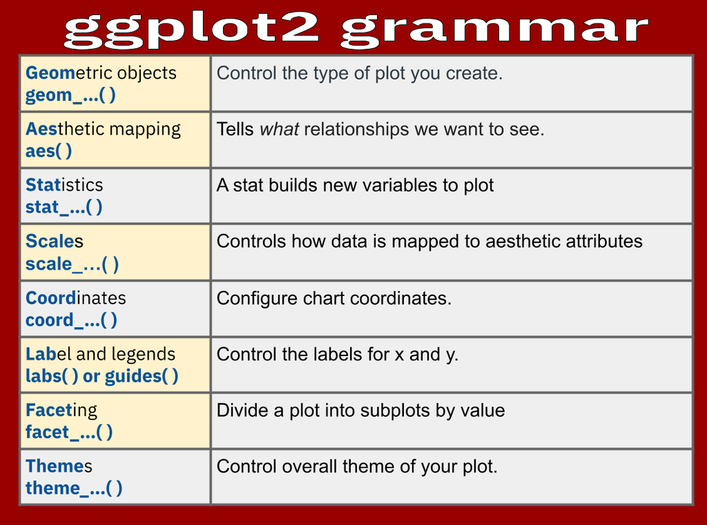

” Elegant Graphics for Data Analysis” states that “every ggplot2 plot has three key components:

- data,
- A set of aesthetic mappings between variables in the data and visual properties, and
- At least one layer which describes how to render each observation. Layers are usually created with a geom function.”

### One Continuous variable

Create a basic visualization that examines a continuous variable of interest.

#### Which online course had the largest enrollment numbers?

Which variable should we be looking at?

#### **👉 Your Turn** **⤵**

```r
#inspect at the data frame
data_to_explore
```

```
## # A tibble: 943 × 34
##    student_id subject semester section total_points_possible total_points_earned
##    <chr>      <chr>   <chr>    <chr>                   <dbl>               <dbl>
##  1 43146      FrScA   S216     02                       1217               1150
##  2 44638      OcnA    S116     01                       1676               1384.
##  3 47448      FrScA   S216     01                       1232               1116
##  4 47979      OcnA    S216     01                       1833               1493.
##  5 48797      PhysA   S116     01                       2225               1995.
##  6 51943      FrScA   S216     03                       1222                 70
##  7 52326      AnPhA   S216     01                       1775               1519.
##  8 52446      PhysA   S116     01                       2225               2198
##  9 53447      FrScA   S116     01                       1212               1173
## 10 53475      FrScA   S116     02                       1212                  0
## # ℹ 933 more rows
## # ℹ 28 more variables: proportion_earned <dbl>, gender <chr>,
## #   enrollment_reason <chr>, enrollment_status <chr>, time_spent <dbl>,
## #   time_spent_hours <dbl>, course_id <chr>, int <dbl>, val <dbl>,
## #   percomp <dbl>, tv <dbl>, q1 <dbl>, q2 <dbl>, q3 <dbl>, q4 <dbl>, q5 <dbl>,
## #   q6 <dbl>, q7 <dbl>, q8 <dbl>, q9 <dbl>, q10 <dbl>, date_x <dttm>,
## #   post_int <dbl>, post_uv <dbl>, post_tv <dbl>, post_percomp <dbl>, …
```

#### Level a. The most basic level for a plot

Includes:

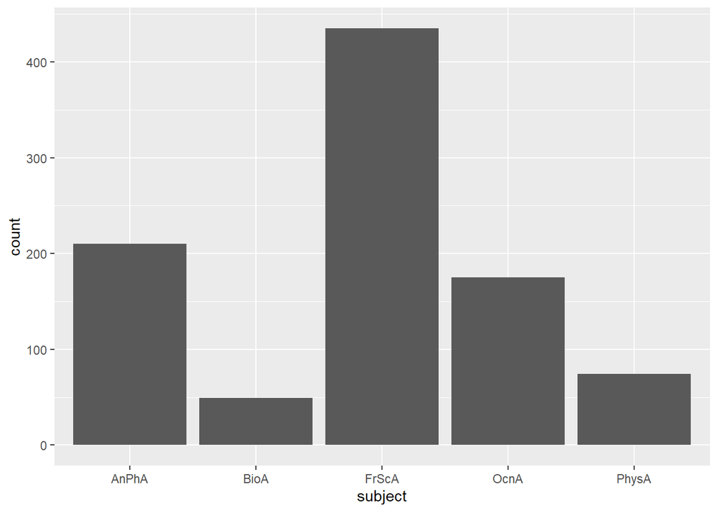

```r
ggplot(data_to_explore, aes(x = subject)) +
  geom_bar()
```

#### Level b. Add another layer with labels

- **title**: “Number of Student Enrollments per Subject”
- **caption**: “Which online courses have had the largest enrollment numbers?”

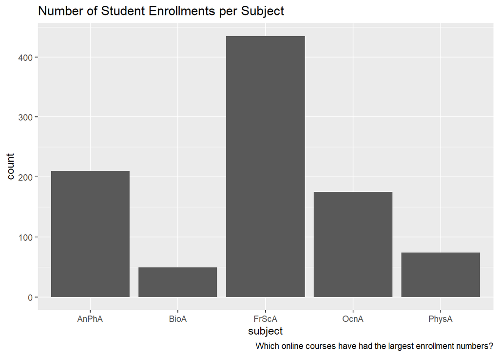

```r
ggplot(data_to_explore, aes(x = subject)) +
  geom_bar() +
  labs(title = "Number of Student Enrollments per Subject",
       caption = "Which online courses have had the largest enrollment numbers?")
```

#### Level c: Add **Scale** with a different color.

- **scale**: fill = gender

##### What can we notice about gender?

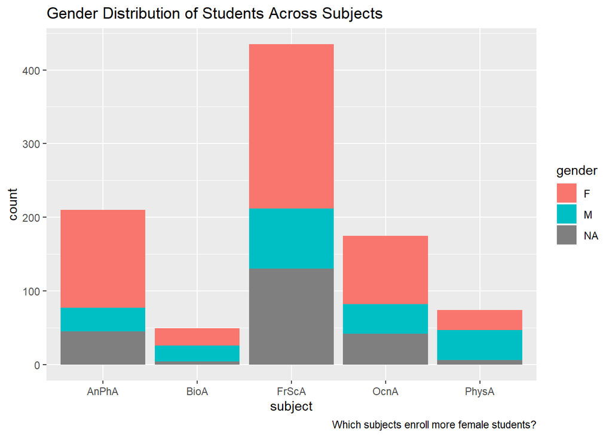

```r
ggplot(data_to_explore, aes(x = subject, fill = gender)) +
  geom_bar() +
  labs(title = "Gender Distribution of Students Across Subjects",
       caption = "Which subjects enroll more female students?")
```

#### Histogram - You try

**NEED HELP? [TRY STHDA](http://www.sthda.com/english/wiki/ggplot2-histogram-plot-quick-start-guide-r-software-and-data-visualization)**

Yours could look like something below…

#### **👉 Your Turn** **⤵**

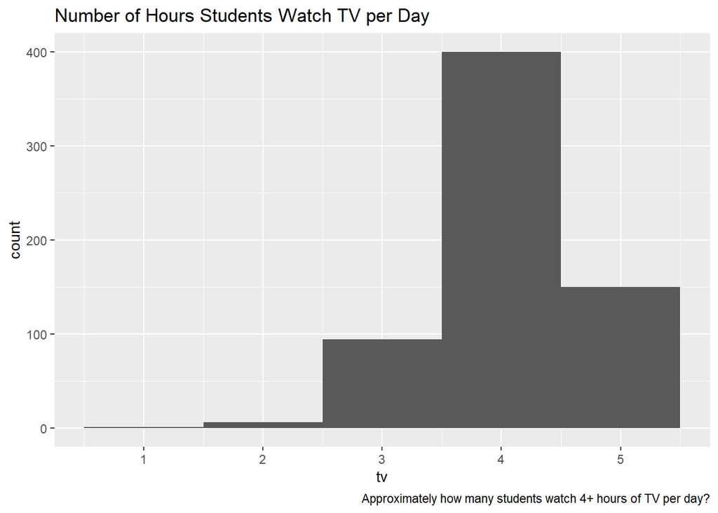

```r
ggplot(data_to_explore, aes(x = tv)) +
  geom_histogram(bins = 5) +
  labs(title = "Number of Hours Students Watch TV per Day",
       caption = "Approximately how many students watch 4+ hours of TV per day?")
```

or maybe you added a `theme()`

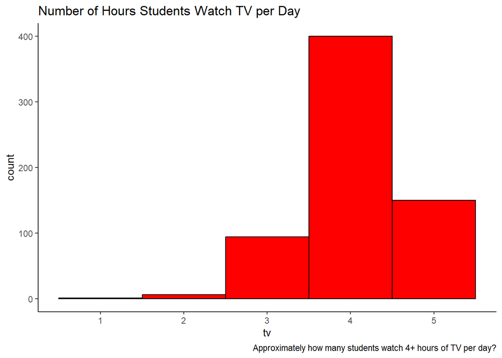

```r
data_to_explore%>%
  ggplot(aes(x= tv))+
  geom_histogram(bins = 5, fill = "red", colour = "black")+
  labs(title = "Number of Hours Students Watch TV per Day",
       caption = "Approximately how many students watch 4+ hours of TV per day?") +
  theme_classic()
```

### Two categorical Variables

Create a basic visualization that examines the relationship between two categorical variables.

#### **👉 Your Turn** **⤵**

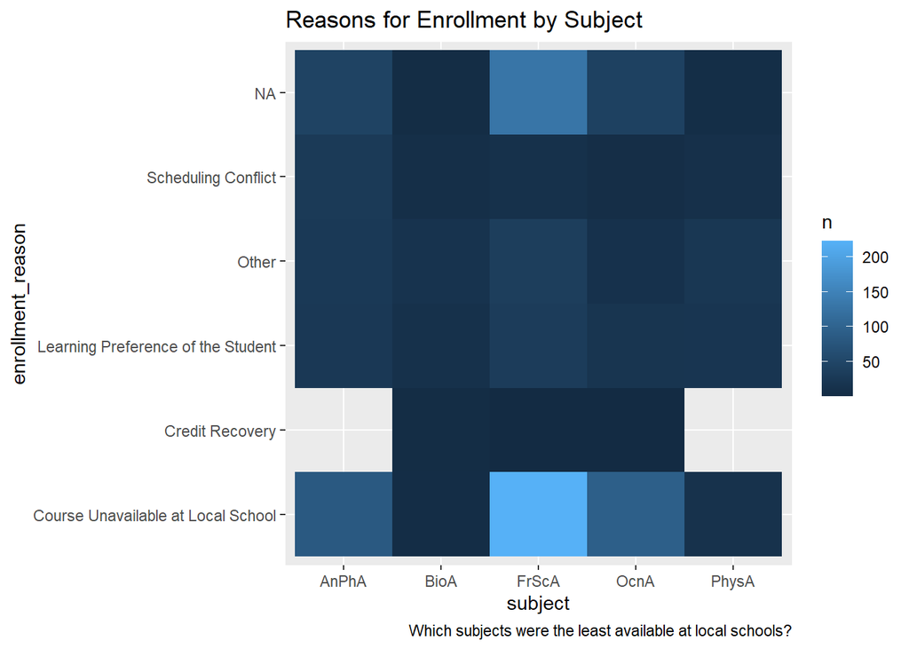

```r
data_to_explore %>%
  count(subject, enrollment_reason) %>%
  ggplot() +
  geom_tile(mapping = aes(x = subject,
                          y = enrollment_reason,
                          fill = n)) +
  labs(title = "Reasons for Enrollment by Subject",
       caption = "Which subjects were the least available at local schools?")
```

### Two continuous variables

Create a basic visualization that examines the relationship between two continuous variables.

#### Scatter plot

##### REASERCH QUESTION: Can we predict the grade on a course from the time spent in the course LMS?

Which variables should we be looking at?

```r
#look at the data frame
data_to_explore
```

```
## # A tibble: 943 × 34
##    student_id subject semester section total_points_possible total_points_earned
##    <chr>      <chr>   <chr>    <chr>                   <dbl>               <dbl>
##  1 43146      FrScA   S216     02                       1217               1150
##  2 44638      OcnA    S116     01                       1676               1384.
##  3 47448      FrScA   S216     01                       1232               1116
##  4 47979      OcnA    S216     01                       1833               1493.
##  5 48797      PhysA   S116     01                       2225               1995.
##  6 51943      FrScA   S216     03                       1222                 70
##  7 52326      AnPhA   S216     01                       1775               1519.
##  8 52446      PhysA   S116     01                       2225               2198
##  9 53447      FrScA   S116     01                       1212               1173
## 10 53475      FrScA   S116     02                       1212                  0
## # ℹ 933 more rows
## # ℹ 28 more variables: proportion_earned <dbl>, gender <chr>,
## #   enrollment_reason <chr>, enrollment_status <chr>, time_spent <dbl>,
## #   time_spent_hours <dbl>, course_id <chr>, int <dbl>, val <dbl>,
## #   percomp <dbl>, tv <dbl>, q1 <dbl>, q2 <dbl>, q3 <dbl>, q4 <dbl>, q5 <dbl>,
## #   q6 <dbl>, q7 <dbl>, q8 <dbl>, q9 <dbl>, q10 <dbl>, date_x <dttm>,
## #   post_int <dbl>, post_uv <dbl>, post_tv <dbl>, post_percomp <dbl>, …
```

#### Level a. The most basic level for a plot

Includes:

- **data**: data_to_explore.csv
- **`aes()` function** - two continuous variables
  - time spent in hours mapped to x position
  - proportion earned mapped to y position
- **Geom**: `geom_point()` function - Scatter plot

#### **👉 Your Turn** **⤵**

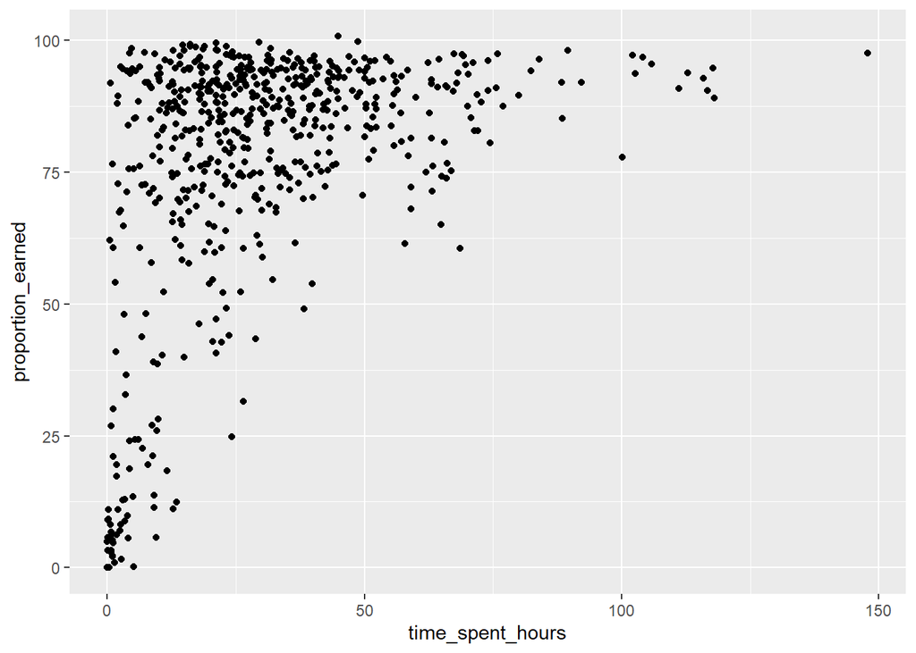

```r
#layer 1: add data and aesthetics mapping
ggplot(data_to_explore,
       aes(x = time_spent_hours,
           y = proportion_earned)) +
#layer 2: +  geom function type
  geom_point()
```

#### Level b. Add another layer with labels

- Add a **title**: “How Time Spent on Course LMS is Related to Points Earned in the course”
- Add a **x label**: “Time Spent (Hours)”
- Add a **y label**: “Proportion of Points Earned”

#### **👉 Your Turn** **⤵**

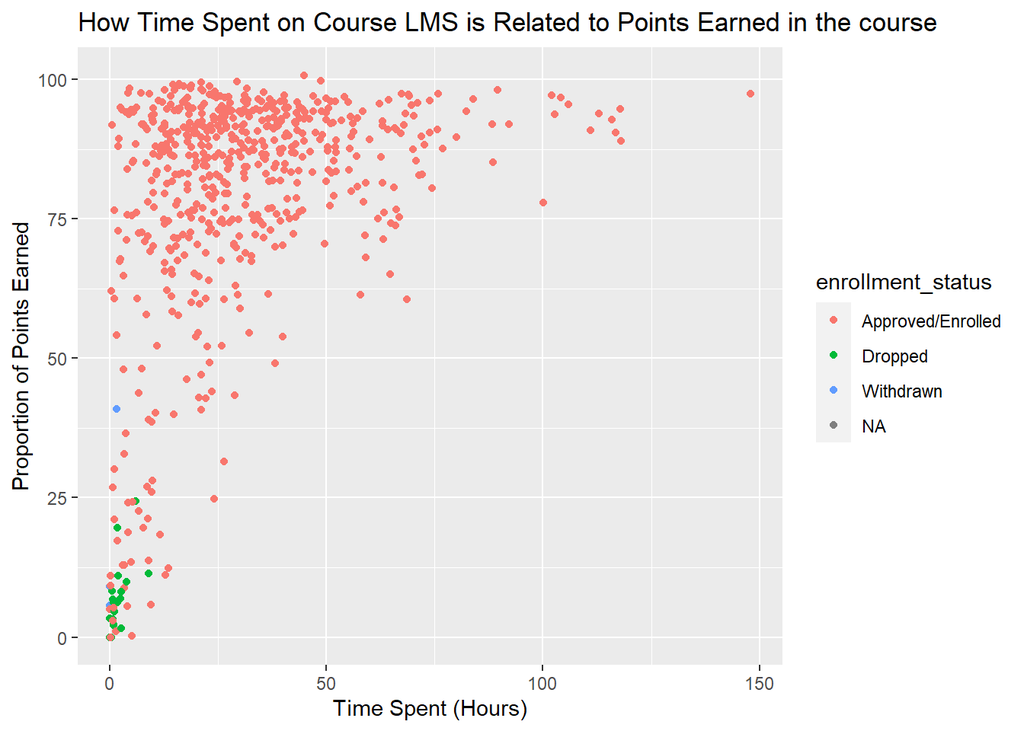

```r
#layer 1: add data and aesthetics mapping
#layer 3: add color scale by type
ggplot(data_to_explore,
       aes(x = time_spent_hours,
           y = proportion_earned,
           color = enrollment_status)) +
#layer 2: +  geom function type
  geom_point() +
#layer 4: add labels
  labs(title="How Time Spent on Course LMS is Related to Points Earned in the course",
       x="Time Spent (Hours)",
       y = "Proportion of Points Earned")
```

#### Level c. Add **Scale** with a different color.

##### RESEARCH QUESTION: Can we notice anything about enrollment status?

- Add **scale**: color = enrollment_status

#### **👉 Your Turn** **⤵**

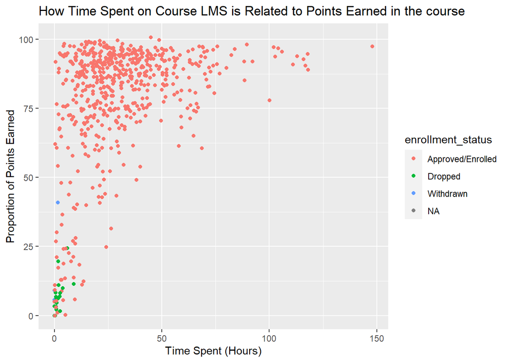

```r
#layer 1: add data and aesthetics mapping
#layer 4: add color scale by type
ggplot(data_to_explore,
       aes(x = time_spent_hours,
           y = proportion_earned,
           color = enrollment_status)) +
#layer 2: +  geom function type
  geom_point() +
#layer 3: add labels
  labs(title="How Time Spent on Course LMS is Related to Points Earned in the course",
       x="Time Spent (Hours)",
       y = "Proportion of Points Earned")
```

#### Level d. Divide up graphs using facet to visualize by subject.

- Add **facet** with facet_wrap() function: by subject

#### **👉 Your Turn** **⤵**

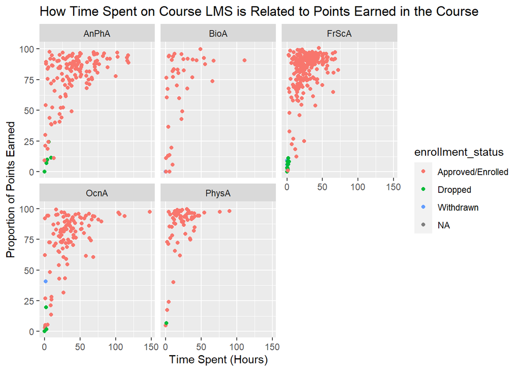

```r
#layer 1: add data and aesthetics mapping
#layer 3: add color scale by type
ggplot(data_to_explore, aes(x = time_spent_hours, y = proportion_earned, color = enrollment_status)) +
#layer 2: +  geom function type
  geom_point() +
#layer 4: add labels
  labs(title="How Time Spent on Course LMS is Related to Points Earned in the Course",
       x="Time Spent (Hours)",
       y = "Proportion of Points Earned")+
#layer 5: add facet wrap
  facet_wrap(~ subject)
```

#### Level e. How can we remove NA’s from plot? and What will the code look like without the comments?

You can pipe the data with the dataframe and use `drop_na()` function.

- use **data** then,
- use `drop_na` function to remove na’s from enrollment status then,
- add `ggplot` function like above

#### **👉 Your Turn** **⤵**

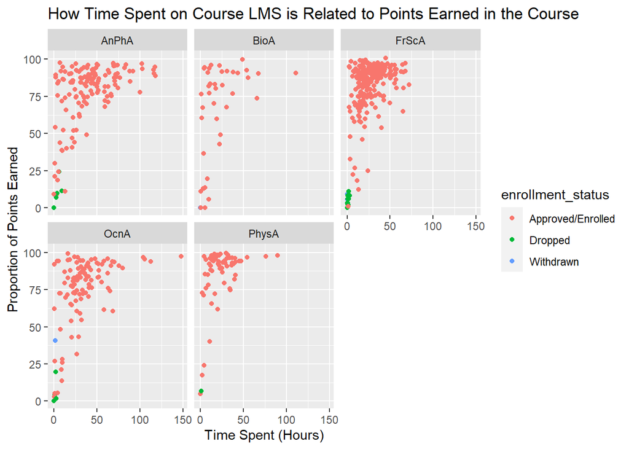

```r
data_to_explore %>%
  drop_na(enrollment_status) %>%
  ggplot(aes(x = time_spent_hours,
             y = proportion_earned,
             color = enrollment_status)) +
  geom_point() +
  labs(title="How Time Spent on Course LMS is Related to Points Earned in the Course",
       x="Time Spent (Hours)",
       y = "Proportion of Points Earned")+
  facet_wrap(~ subject)
```

## Model

Quantify the insights using mathematical models. As highlighted in.[Chapter 3 of Data Science in Education Using R](https://datascienceineducation.com/c03.html), the.**Model**.step of the data science process entails “using statistical models, from simple to complex, to understand trends and patterns in the data.” The authors note that while descriptive statistics and data visualization during the**Explore**step can help us to identify patterns and relationships in our data, statistical models can be used to help us determine if relationships, patterns and trends are actually meaningful.

##### A. Correlation Matrix

As highlighted in @macfadyen2010, scatter plots are a useful initial approach for identifying potential correlational trends between variables under investigation, but to further interrogate the significance of selected variables as indicators of student achievement, a simple correlation analysis of each variable with student final grade can be conducted.

There are two efficient ways to create correlation matrices, one that is best for internal use, and one that is best for inclusion in a manuscript. The {corrr} package provides a way to create a correlation matrix in a {tidyverse}-friendly way. Like for the {skimr} package, it can take as little as a line of code to create a correlation matrix. If not familiar, a correlation matrix is a table that presents how *all of the variables* are related to *all of the other variables*.

#### **👉 Your Turn** **⤵**

```r
#install corrr package if this is your first time

# read in library
library(corrr)
```

Look and see if there is a simple correlation between time spent and student achievement.

#### **👉 Your Turn** **⤵**

```r
data_to_explore %>%
  select(proportion_earned, time_spent_hours) %>%
  correlate()
```

```
## Correlation computed with
## • Method: 'pearson'
## • Missing treated using: 'pairwise.complete.obs'
```

```
## # A tibble: 2 × 3
##   term              proportion_earned time_spent_hours
##   <chr>                         <dbl>            <dbl>
## 1 proportion_earned            NA                0.438
## 2 time_spent_hours              0.438           NA
```

**For printing** purposes,the `fashion()` function can be added for converting a correlation data frame into a matrix with the correlations cleanly formatted (leading zeros removed; spaced for signs) and the diagonal (or any NA) left blank.

```r
#add fashion function
data_to_explore %>%
  select(proportion_earned, time_spent_hours) %>%
  correlate() %>%
  rearrange() %>%
  shave() %>%
  fashion()
```

```
## Correlation computed with
## • Method: 'pearson'
## • Missing treated using: 'pairwise.complete.obs'
```

```
##                term proportion_earned time_spent_hours
## 1 proportion_earned
## 2  time_spent_hours               .44
```

What other variables would you like to check out?

##### B. APA Formatted Table

While {corrr} is a nice package to quickly create a correlation matrix, you may wish to create one that is ready to be added directly to a dissertation or journal article. {apaTables} is great for creating more formal forms of output that can be added directly to an APA-formatted manuscript; it also has functionality for regression and other types of model output. It is not as friendly to {tidyverse} functions; first, we need to select only the variables we wish to correlate.

Then, we can use that subset of the variables as the argument to the`apa.cor.table()` function.

Run the following code to create a subset of the larger `data_to_explore` data frame with the variables you wish to correlate, then create a correlation table using `apa.cor.table()`.

#### **👉 Your Turn** **⤵**

```r
# read in apatables library
library(apaTables)

data_to_explore_subset <- data_to_explore %>%
  select(time_spent_hours, proportion_earned, int)

apa.cor.table(data_to_explore_subset)
```

```
##
##
## Means, standard deviations, and correlations with confidence intervals
##
##
##   Variable             M     SD    1           2
##   1. time_spent_hours  30.48 22.72
##
##   2. proportion_earned 76.23 25.20 .44**
##                                    [.37, .50]
##
##   3. int               4.30  0.60  .08         .14**
##                                    [-.01, .16] [.06, .22]
##
##
## Note. M and SD are used to represent mean and standard deviation, respectively.
## Values in square brackets indicate the 95% confidence interval.
## The confidence interval is a plausible range of population correlations
## that could have caused the sample correlation (Cumming, 2014).
##  * indicates p < .05. ** indicates p < .01.
##
```

This may look nice, but how to actually add this into a dissertation or article that you might be interested in publishing?

Read the documentation for `apa.cor.table()` by running `?apa.cor.table()` in the console. Look through the documentation and examples to understand how to output a file with the formatted correlation table, and then run the code to do that with your subset of the `data_to_explore` data frame.

```r
apa.cor.table(data_to_explore_subset, filename = "cor-table.doc")
```

```
##
##
## Means, standard deviations, and correlations with confidence intervals
##
##
##   Variable             M     SD    1           2
##   1. time_spent_hours  30.48 22.72
##
##   2. proportion_earned 76.23 25.20 .44**
##                                    [.37, .50]
##
##   3. int               4.30  0.60  .08         .14**
##                                    [-.01, .16] [.06, .22]
##
##
## Note. M and SD are used to represent mean and standard deviation, respectively.
## Values in square brackets indicate the 95% confidence interval.
## The confidence interval is a plausible range of population correlations
## that could have caused the sample correlation (Cumming, 2014).
##  * indicates p < .05. ** indicates p < .01.
##
```

##### C. Predict Academic Achievement

##### Linear Regression

In brief, a linear regression model involves estimating the relationships between one or more *independent variables* with one dependent variable. Mathematically, it can be written like the following.

$$\operatorname{dependentvar} = \beta_{0} +
\beta_{1}(\operatorname{independentvar}) + \epsilon$$

Does time spent predict grade earned?

```r
lm(proportion_earned ~ time_spent_hours,
   data = data_to_explore)
```

```
##
## Call:
## lm(formula = proportion_earned ~ time_spent_hours, data = data_to_explore)
##
## Coefficients:
##      (Intercept)  time_spent_hours
##          62.4306            0.4792
```

The following code estimates a model in which `proportion_earned`, the proportion of points students earned, is the dependent variable. It is predicted by one independent variable.

- Add + `int`, after `time_spent_hours` for students’ self-reported interest in science.

#### **👉 Your Turn** **⤵**

```r
# Add predictor variable for science
lm(proportion_earned ~ time_spent_hours + int,
   data = data_to_explore)
```

```
##
## Call:
## lm(formula = proportion_earned ~ time_spent_hours + int, data = data_to_explore)
##
## Coefficients:
##      (Intercept)  time_spent_hours               int
##          44.9657            0.4255            4.6283
```

We can save the output of the function to an object—let’s say `m1`, standing for model 1. We can then use the `summary()` function built into R to view a much more feature-rich summary of the estimated model.

```r
# save the model 1
m1 <- lm(proportion_earned ~ time_spent_hours + int, data = data_to_explore)
```

Run a summary model for the model you just created called, `m1.` #### **👉 Your Turn** **⤵**

```r
#run the summary
summary(m1)
```

```
##
## Call:
## lm(formula = proportion_earned ~ time_spent_hours + int, data = data_to_explore)
##
## Residuals:
##     Min      1Q  Median      3Q     Max
## -66.705  -7.836   5.049  14.695  35.766
##
## Coefficients:
##                  Estimate Std. Error t value Pr(>|t|)
## (Intercept)       44.9657     6.6488   6.763 3.54e-11 ***
## time_spent_hours   0.4255     0.0410  10.378  < 2e-16 ***
## int                4.6283     1.5364   3.012  0.00271 **
## ---
## Signif. codes:  0 '***' 0.001 '**' 0.01 '*' 0.05 '.' 0.1 ' ' 1
##
## Residual standard error: 21.42 on 536 degrees of freedom
##   (404 observations deleted due to missingness)
## Multiple R-squared:  0.1859, Adjusted R-squared:  0.1828
## F-statistic: 61.18 on 2 and 536 DF,  p-value: < 2.2e-16
```

##### Summarize predictors

The `summarize()` function from the {dplyr} package used to create summary statistics such as the mean, standard deviation, or the minimum or maximum of a value.

At its core, think of `summarize()` as a function that returns a single value (whether it’s a mean, median, standard deviation—whichever!) that summarizes a single column.

In the space below find the mean interest of students. `summarize()`

```r
data_to_explore %>%
  summarize(mean_interest = mean(int, na.rm = TRUE))
```

```
## # A tibble: 1 × 1
##   mean_interest
##           <dbl>
## 1          4.30
```

Now let’s look at the mean of `time_spent_hours` and remove any NA’s. - save it to a new variable called `mean_time`

#### **👉 Your Turn** **⤵**

```r
data_to_explore %>%
  summarize(mean_time = mean(time_spent_hours, na.rm = TRUE))
```

```
## # A tibble: 1 × 1
##   mean_time
##       <dbl>
## 1      30.5
```

Let’s save this as a nice APA table for possible publication

```r
apa.reg.table(m1, filename = "lm-table.doc")
```

```
##
##
## Regression results using proportion_earned as the criterion
##
##
##         Predictor       b       b_95%_CI beta  beta_95%_CI sr2  sr2_95%_CI
##       (Intercept) 44.97** [31.90, 58.03]
##  time_spent_hours  0.43**   [0.34, 0.51] 0.41 [0.33, 0.48] .16  [.11, .22]
##               int  4.63**   [1.61, 7.65] 0.12 [0.04, 0.19] .01 [-.00, .03]
##
##
##
##      r             Fit
##
##  .41**
##  .15**
##            R2 = .186**
##        95% CI[.13,.24]
##
##
## Note. A significant b-weight indicates the beta-weight and semi-partial correlation are also significant.
## b represents unstandardized regression weights. beta indicates the standardized regression weights.
## sr2 represents the semi-partial correlation squared. r represents the zero-order correlation.
## Square brackets are used to enclose the lower and upper limits of a confidence interval.
## * indicates p < .05. ** indicates p < .01.
##
```

- load `apaTables` library

```r
#load packages

# use the {apaTables} package to create a nice regression table that could be used for later publication.
apa.reg.table(m1, filename = "lm-table.doc")
```

```
##
##
## Regression results using proportion_earned as the criterion
##
##
##         Predictor       b       b_95%_CI beta  beta_95%_CI sr2  sr2_95%_CI
##       (Intercept) 44.97** [31.90, 58.03]
##  time_spent_hours  0.43**   [0.34, 0.51] 0.41 [0.33, 0.48] .16  [.11, .22]
##               int  4.63**   [1.61, 7.65] 0.12 [0.04, 0.19] .01 [-.00, .03]
##
##
##
##      r             Fit
##
##  .41**
##  .15**
##            R2 = .186**
##        95% CI[.13,.24]
##
##
## Note. A significant b-weight indicates the beta-weight and semi-partial correlation are also significant.
## b represents unstandardized regression weights. beta indicates the standardized regression weights.
## sr2 represents the semi-partial correlation squared. r represents the zero-order correlation.
## Square brackets are used to enclose the lower and upper limits of a confidence interval.
## * indicates p < .05. ** indicates p < .01.
##
```

## Communicate

For your final Your Turn, your goal is to distill our analysis into a FLEXBOARD “data product” designed to illustrate key findings. Feel free to use the template in the lab 4 folder.

The final step in the workflow/process is sharing the results of your analysis with wider audience. Krumm et al. @krumm2018 have outlined the following 3-step process for communicating with education stakeholders findings from an analysis:

1. **Select.** Communicating what one has learned involves selecting among those analyses that are most important and most useful to an intended audience, as well as selecting a form for displaying that information, such as a graph or table in static or interactive form, i.e. a “data product.”
2. **Polish**. After creating initial versions of data products, research teams often spend time refining or polishing them, by adding or editing titles, labels, and notations and by working with colors and shapes to highlight key points.
3. **Narrate.** Writing a narrative to accompany the data products involves, at a minimum, pairing a data product with its related research question, describing how best to interpret the data product, and explaining the ways in which the data product helps answer the research question and might be used to inform new analyses or a “change idea” for improving student learning.

#### **👉 Your Turn** **⤵**

Create a Data Story with our current data set - Develop a research question - Add ggplot visualizations - Modeling visualizations - add a short write up for the intended stakeholders